# HW1_HYUNKO

Hyun Ko

2021 12 10

## 1

Part 1: Write discriminant() and quadratic.formula() functions to solve the quadratic equation a*x^2 + b*x + c = 0.

———- Part 1(a) ———- Write a function “discriminant()” that takes three numeric parameters, a, b, and c, related to the quadratic equation a*x^2 + b*x + c = 0 and returns the discriminant b^2 - 4ac.

```r
discriminant = function(a, b, c) {
 return(b ** 2 - 4 * a* c)
}
stopifnot(isTRUE(all.equal(discriminant(0, 0,  0), 0)))
stopifnot(isTRUE(all.equal(discriminant(0, 0,  1), 0)))
stopifnot(isTRUE(all.equal(discriminant(0, 1,  0), 1)))
stopifnot(isTRUE(all.equal(discriminant(0, 1,  1), 1)))
stopifnot(isTRUE(all.equal(discriminant(1, 0,  0), 0)))
stopifnot(isTRUE(all.equal(discriminant(1, 0,  1), -4)))
stopifnot(isTRUE(all.equal(discriminant(1, 1,  1), -3)))
stopifnot(isTRUE(all.equal(discriminant(1, -1,  -1), 5)))
stopifnot(isTRUE(all.equal(discriminant(-1, -1,  -1), -3)))
```

———- Part 1(b) ———- Write a function “quadratic.formula()” with three numeric parameters, a, b, and c related to the quadratic equation a*x^2 + b*x + c = 0. Its return value is as follows:

If a is 0, return NULL (because “0x^2 + bx + c = 0” isn’t a quadratic equation).

If there are no real-number solutions (because the discriminant is negative), return a numeric vector of length 0. (Use your discriminant() function to find the discriminant.)

Otherwise return a vector of the two (possibly identical) solutions to a*x^2 + b*x + c = 0. If the two solutions are different, the smaller solution should be first in the vector.

Note: Call your discriminant() function to get the discriminant.

```r
quadratic.formula = function(a, b, c) {
  if (a == 0) {
    return (NULL)
  }

  discriminant = discriminant(a, b, c)
  if (discriminant < 0) {
    return (numeric(0))
  }
  else if (discriminant == 0) {
    return(-b / 2*a)
  }
  else {
    small_nominator = -b - sqrt(b**2- 4 * a * c)
    big_nominator = -b + sqrt(b**2- 4 * a * c)
    denominator = 2 * a
    small_result = small_nominator / denominator
    big_result = big_nominator / denominator
    return (c(small_result, big_result))
  }
}
stopifnot(isTRUE(all.equal(quadratic.formula(0, 0,  0), NULL)))
stopifnot(isTRUE(all.equal(quadratic.formula(1, 0,  1), numeric(0))))
stopifnot(isTRUE(all.equal(quadratic.formula(1, 0, -1), c(-1, 1))))
stopifnot(isTRUE(all.equal(quadratic.formula(1, 0, -4), c(-2, 2))))
stopifnot(isTRUE(all.equal(quadratic.formula(2, 0, -8), c(-2, 2))))
stopifnot(isTRUE(all.equal(quadratic.formula(1, 5,  6), c(-3,-2))))
stopifnot(isTRUE(all.equal(quadratic.formula(1, 1, -6), c(-3, 2))))
```

## 2

———- Part 2(a) ———- Get the required data. Do this part outside this R script. Make a folder called “babyData”. Save the file www.ssa.gov/OACT/babynames/names.zip into your babyData folder. Unzip names.zip to see NationalReadMe.pdf and 140 data files, one for each year from 1880 through 2019 (or the year from the last file shown below): NationalReadMe.pdf yob1880.txt yob1881.txt … yob2018.txt yob2019.txt (or the last file in the similar format with a number even larger)

The file “NationalReadMe.pdf” says this: For each year of birth YYYY after 1879, we created comma-delimited file called yobYYYY.txt. Each record in the individual annual files has the format “name,sex,number,” where name is 2 to 15 characters, sex is M (male) or F (female) and “number” is the number of occurrences of the name.

For example, here are the start and end of yob2010.txt: Isabella,F,22921 Sophia,F,20646 … Zyran,M,5 Zzyzx,M,5

(The idea for this assignment came from Nick Parlante’s “Nifty Assignment Archive”, http://nifty.stanford.edu/2005/NameSurfer. I took a class from Nick, an excellent and hilarious teacher, in about 1991.)

———- Part 2(b) ———- Write a function “baby()” with three character string parameters: name, sex, and data.

It should read the “.txt” files in the data folder and get the proportion of babies born each year, 1880 to 2019 (or the year from the last file shown above), of the specified name and sex.

It should make a graph showing, on the x-axis, the years from 1880 to 2019 (or the year from the last file shown above), and on the y-axis, the proportion of babies born with the specified name and sex for each year. Include the title “Proportion of babies named by year” (where “” is replaced by the name provided by the caller), the x-axis label “Year” and the y-axis label “Proportion of babies”. It should return the vector of proportions.

```r
baby = function(name, sex, data) {
  proportions = c()

  for (i in seq(1880,2020)) {
    path = paste(data,"/names/yob", as.character(i), ".txt", sep="")
    txt_file = read.delim(path, header = FALSE)$V1
    target_data = 0
    total_population = 0

    for (j in (1:length(txt_file))){
      person_name = unlist(strsplit(txt_file[j], ","))[1]
      person_sex = unlist(strsplit(txt_file[j], ","))[2]
      person_data = as.numeric(unlist(strsplit(txt_file[j], ","))[3])

      if (person_name == name & person_sex == sex){
        target_data = target_data + person_data
      }
      total_population = total_population + person_data
    }
    ratio = as.numeric(( target_data / total_population ))
    sprintf(ratio, fmt = '%#.3f')
    proportions <- append(proportions, ratio)
  }
  return(proportions)
}
```

———- Part 2(c) ———- Call your function on “Emma”, “F”, and “babyData”. (I’ve done this for you.)

Check that your solution matches mine. (I’ve done this for you.)

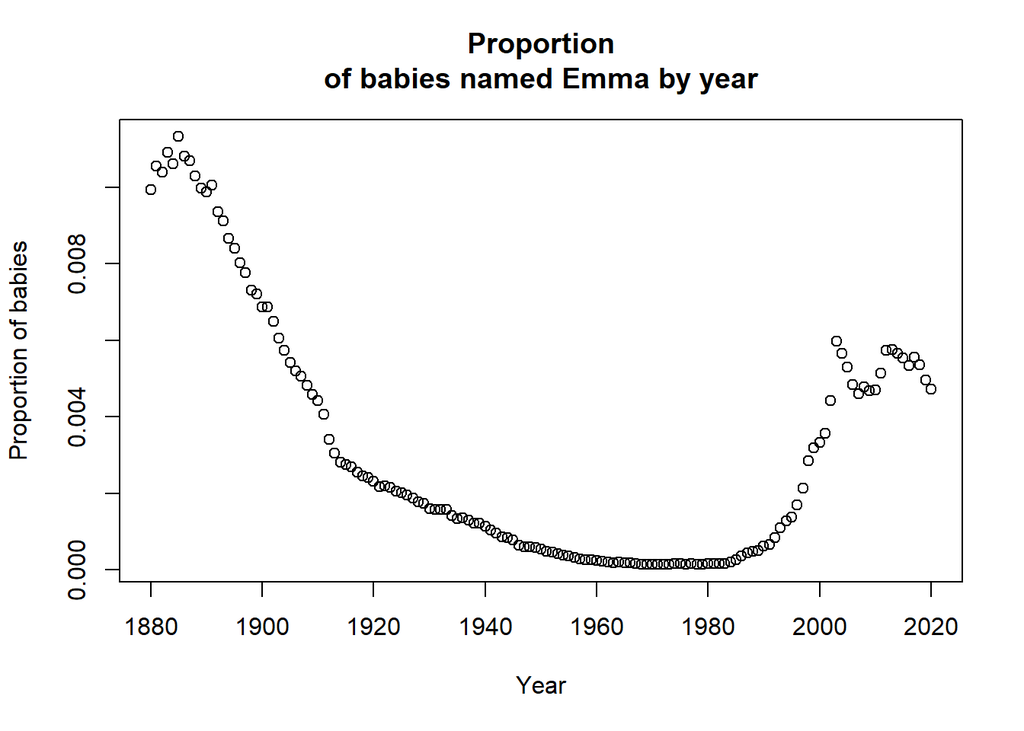

```r
proportion = baby(name="Emma", sex="F", data="babyData")

emma.proportions =
  c(0.00994, 0.01056, 0.0104, 0.01091, 0.01063, 0.01133, 0.01083,
    0.0107, 0.01031, 0.00998, 0.00989, 0.01006, 0.00935, 0.00913,
    0.00867, 0.00841, 0.00803, 0.00778, 0.00731, 0.00721, 0.00687,
    0.00686, 0.0065, 0.00605, 0.00573, 0.00542, 0.00519, 0.00506,
    0.00482, 0.00457, 0.00441, 0.00406, 0.0034, 0.00306, 0.0028,
    0.00275, 0.0027, 0.00255, 0.00245, 0.00241, 0.00231, 0.00217,
    0.00219, 0.00216, 0.00206, 0.00202, 0.00195, 0.00187, 0.00178,
    0.00173, 0.0016, 0.00157, 0.00158, 0.00158, 0.00142, 0.00134,
    0.00136, 0.00129, 0.00121, 0.00122, 0.00113, 0.00105, 0.00095,
    0.00086, 0.00084, 0.00077, 0.00065, 0.00059, 0.00061, 0.00057,
    0.00054, 0.00047, 0.00045, 0.00041, 0.00038, 0.00036, 0.00033,
    0.00029, 0.00026, 0.00025, 0.00024, 0.00021, 2e-04, 0.00018,
    2e-04, 0.00018, 0.00018, 0.00017, 0.00015, 0.00015, 0.00015,
    0.00014, 0.00014, 0.00014, 0.00016, 0.00016, 0.00014, 0.00015,
    0.00014, 0.00015, 0.00015, 0.00015, 0.00016, 0.00016, 0.00019,
    0.00027, 0.00035, 0.00044, 0.00048, 5e-04, 0.00061, 0.00067,
    0.00084, 0.00109, 0.00128, 0.00138, 0.00168, 0.00214, 0.00284,
    0.00318, 0.00332, 0.00356, 0.00443, 0.00597, 0.00566, 0.00529,
    0.00484, 0.0046, 0.00479, 0.00469, 0.0047, 0.00515, 0.00573,
    0.00575, 0.00566, 0.00554, 0.00533, 0.00556, 0.00535, 0.00496,
    0.00471)
stopifnot(isTRUE(all.equal(proportion, emma.proportions, tolerance=.001)))

year_range = c(1880:2020)
name = "Emma"
plot(x=year_range, y=proportion, main=paste("Proportion
of babies named", name, "by year"), xlab="Year", ylab="Proportion of babies")
```